# Lab8-PCA+KPCA-[ameo-dataset]

## 16BCE1384

## Repository-link: https://github.com/raj1603chdry/CSE4020-MachineLearningLabs

### Importing the libraries

```python
%matplotlib inline
import numpy as np
import pandas as pd
import matplotlib.pyplot as plt
from matplotlib.colors import ListedColormap
import seaborn as sb
from scipy import stats
import seaborn as sns;sns.set()
from sklearn.model_selection import train_test_split
from sklearn.metrics import accuracy_score
from sklearn.decomposition import PCA
from sklearn.decomposition import KernelPCA
from sklearn.svm import SVC
```

### Importing the dataset

```python
X = pd.read_csv('../datasets/ameo_dataset/processed_dataset/X.csv')
y = pd.read_csv('../datasets/ameo_dataset/processed_dataset/y_cat.csv')
```

**Splitting the dataset into training set and test set**

```python
X_train, X_test, y_train, y_test = train_test_split(X, y, test_size = 0.2, random_state = 100)
```

```python
X.head()
```

|  | 10percentage | 12percentage | collegeGPA | English | Logical | Quant | Domain | ComputerProgramming | ElectronicsAndSemicon | ComputerScience | ... | GraduationYear_2016 | GraduationYear_2017 | Gender_f | Gender_m | Degree_B.Tech/B.E. | Degree_M.Sc. (Tech.) | Degree_M.Tech./M.E. | Degree_MCA | CollegeTier_1 | CollegeTier_2 |
| --- | --- | --- | --- | --- | --- | --- | --- | --- | --- | --- | --- | --- | --- | --- | --- | --- | --- | --- | --- | --- | --- |
| 0 | 84.3 | 95.8 | 78.00 | 515 | 585 | 525 | 0.635979 | 445 | 0 | 0 | ... | 0 | 0 | 1 | 0 | 1 | 0 | 0 | 0 | 0 | 1 |
| 1 | 85.4 | 85.0 | 70.06 | 695 | 610 | 780 | 0.960603 | 0 | 466 | 0 | ... | 0 | 0 | 0 | 1 | 1 | 0 | 0 | 0 | 0 | 1 |
| 2 | 85.0 | 68.2 | 70.00 | 615 | 545 | 370 | 0.450877 | 395 | 0 | 0 | ... | 0 | 0 | 1 | 0 | 1 | 0 | 0 | 0 | 0 | 1 |
| 3 | 85.6 | 83.6 | 74.64 | 635 | 585 | 625 | 0.974396 | 615 | 0 | 0 | ... | 0 | 0 | 0 | 1 | 1 | 0 | 0 | 0 | 1 | 0 |
| 4 | 78.0 | 76.8 | 73.90 | 545 | 625 | 465 | 0.124502 | 0 | 233 | 0 | ... | 0 | 0 | 0 | 1 | 1 | 0 | 0 | 0 | 0 | 1 |

5 rows × 70 columns

```python
X.columns
```

```
Index(['10percentage', '12percentage', 'collegeGPA', 'English', 'Logical',
       'Quant', 'Domain', 'ComputerProgramming', 'ElectronicsAndSemicon',
       'ComputerScience', 'MechanicalEngg', 'ElectricalEngg', 'TelecomEngg',
       'CivilEngg', 'conscientiousness', 'agreeableness', 'extraversion',
       'nueroticism', 'openess_to_experience', 'Specialization_CE',
       'Specialization_CS', 'Specialization_EC', 'Specialization_EL',
       'Specialization_ME', 'Specialization_other',
       'CollegeState_Andhra Pradesh', 'CollegeState_Assam',
       'CollegeState_Bihar', 'CollegeState_Chhattisgarh', 'CollegeState_Delhi',
       'CollegeState_Goa', 'CollegeState_Gujarat', 'CollegeState_Haryana',
       'CollegeState_Himachal Pradesh', 'CollegeState_Jammu and Kashmir',
       'CollegeState_Jharkhand', 'CollegeState_Karnataka',
       'CollegeState_Kerala', 'CollegeState_Madhya Pradesh',
       'CollegeState_Maharashtra', 'CollegeState_Meghalaya',
       'CollegeState_Orissa', 'CollegeState_Punjab', 'CollegeState_Rajasthan',
       'CollegeState_Sikkim', 'CollegeState_Tamil Nadu',
       'CollegeState_Telangana', 'CollegeState_Union Territory',
       'CollegeState_Uttar Pradesh', 'CollegeState_Uttarakhand',
       'CollegeState_West Bengal', 'GraduationYear_0', 'GraduationYear_2007',
       'GraduationYear_2009', 'GraduationYear_2010', 'GraduationYear_2011',
       'GraduationYear_2012', 'GraduationYear_2013', 'GraduationYear_2014',
       'GraduationYear_2015', 'GraduationYear_2016', 'GraduationYear_2017',
       'Gender_f', 'Gender_m', 'Degree_B.Tech/B.E.', 'Degree_M.Sc. (Tech.)',
       'Degree_M.Tech./M.E.', 'Degree_MCA', 'CollegeTier_1', 'CollegeTier_2'],
      dtype='object')
```

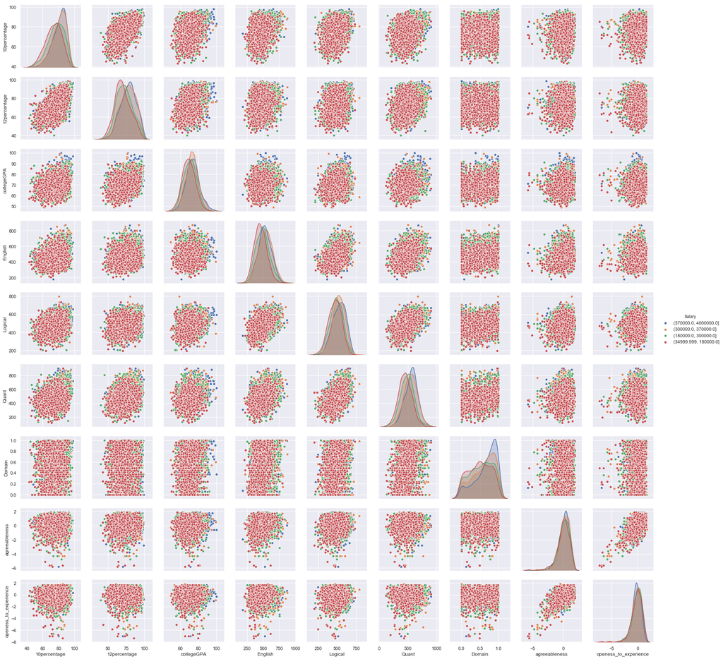

```python
X['Salary'] = y['Salary']
cols = ['10percentage',
        '12percentage',
        'collegeGPA',
        'English',
        'Logical',
        'Quant',
        'Domain',
        'agreeableness',
        'openess_to_experience']
sb.pairplot(X, vars = cols, hue = 'Salary')
```

**Encoding the different salary slots into class labels**

```python
y_train.loc[y_train['Salary']=='(34999.999, 180000.0]','Salary']=1
y_train.loc[y_train['Salary']=='(180000.0, 300000.0]','Salary']=2
y_train.loc[y_train['Salary']=='(300000.0, 370000.0]','Salary']=3
y_train.loc[y_train['Salary']=='(370000.0, 4000000.0]','Salary']=4
y_test.loc[y_test['Salary']=='(34999.999, 180000.0]','Salary']=1
y_test.loc[y_test['Salary']=='(180000.0, 300000.0]','Salary']=2
y_test.loc[y_test['Salary']=='(300000.0, 370000.0]','Salary']=3
y_test.loc[y_test['Salary']=='(370000.0, 4000000.0]','Salary']=4
```

[output not shown]

#### Preparing a grid search cv for the SVM classifier for the whole dataset

```python
from sklearn.pipeline import make_pipeline
from sklearn.model_selection import GridSearchCV
from sklearn.preprocessing import StandardScaler
```

```python
pipe_svc = make_pipeline(StandardScaler(),
                         SVC(random_state = 1))

param_range = [0.0001, 0.001, 0.01, 0.1, 1.0, 10.0, 100.0, 1000.0]

param_grid = [{'svc__C': param_range,
               'svc__kernel': ['linear']},
              {'svc__C': param_range,
               'svc__gamma': param_range,
               'svc__kernel': ['rbf']}]

gs = GridSearchCV(estimator = pipe_svc,
                  param_grid = param_grid,
                  scoring = 'accuracy',
                  cv = 2,
                  n_jobs = -1,
                  verbose = 1)

gs.fit(X_train, y_train.values.ravel())
```

```
Fitting 2 folds for each of 72 candidates, totalling 144 fits
```

```
[Parallel(n_jobs=-1)]: Done  34 tasks      | elapsed:   13.0s
[Parallel(n_jobs=-1)]: Done 144 out of 144 | elapsed:  9.1min finished
```

```
GridSearchCV(cv=2, error_score='raise',
       estimator=Pipeline(memory=None,
     steps=[('standardscaler', StandardScaler(copy=True, with_mean=True, with_std=True)), ('svc', SVC(C=1.0, cache_size=200, class_weight=None, coef0=0.0,
  decision_function_shape='ovr', degree=3, gamma='auto', kernel='rbf',
  max_iter=-1, probability=False, random_state=1, shrinking=True,
  tol=0.001, verbose=False))]),
       fit_params=None, iid=True, n_jobs=-1,
       param_grid=[{'svc__C': [0.0001, 0.001, 0.01, 0.1, 1.0, 10.0, 100.0, 1000.0], 'svc__kernel': ['linear']}, {'svc__C': [0.0001, 0.001, 0.01, 0.1, 1.0, 10.0, 100.0, 1000.0], 'svc__gamma': [0.0001, 0.001, 0.01, 0.1, 1.0, 10.0, 100.0, 1000.0], 'svc__kernel': ['rbf']}],
       pre_dispatch='2*n_jobs', refit=True, return_train_score='warn',
       scoring='accuracy', verbose=1)
```

```python
print(gs.best_score_)
print(gs.best_params_)
```

```
0.46028767979987495
{'svc__C': 1.0, 'svc__gamma': 0.01, 'svc__kernel': 'rbf'}
```

```python
clf = gs.best_estimator_
clf.fit(X_train, y_train.values.ravel())
```

```
Pipeline(memory=None,
     steps=[('standardscaler', StandardScaler(copy=True, with_mean=True, with_std=True)), ('svc', SVC(C=1.0, cache_size=200, class_weight=None, coef0=0.0,
  decision_function_shape='ovr', degree=3, gamma=0.01, kernel='rbf',
  max_iter=-1, probability=False, random_state=1, shrinking=True,
  tol=0.001, verbose=False))])
```

```python
print('Train Accuracy: %.3f' % (clf.score(X_train, y_train)*100))
print('Test Accuracy: %.3f' % (clf.score(X_test, y_test)*100))
```

```
Train Accuracy: 57.598
Test Accuracy: 43.375
```

#### Using the 70 columns of the dataset, a training accuracy of 57.6% and test accuracy of 43.4% is achieved using 'rbf' kernel with C = 1.0 and gamma = 0.01

### PCA with n_components = 2

```python
pca = PCA(n_components = 2)
X_train_pca = pca.fit_transform(X_train)
X_test_pca = pca.fit_transform(X_test)
```

```python
pipe_svc = make_pipeline(StandardScaler(),
                         SVC(random_state = 1))

param_range = [0.0001, 0.001, 0.01, 0.1, 1.0, 10.0, 100.0, 1000.0]

param_grid = [{'svc__C': param_range,
               'svc__kernel': ['linear']},
              {'svc__C': param_range,
               'svc__gamma': param_range,
               'svc__kernel': ['rbf']}]

gs = GridSearchCV(estimator = pipe_svc,
                  param_grid = param_grid,
                  scoring = 'accuracy',
                  cv = 2,
                  n_jobs = -1,
                  verbose = 1)

gs.fit(X_train_pca, y_train.values.ravel())
```

```
Fitting 2 folds for each of 72 candidates, totalling 144 fits
```

```
[Parallel(n_jobs=-1)]: Done  54 tasks      | elapsed:    2.2s
[Parallel(n_jobs=-1)]: Done 144 out of 144 | elapsed:   27.2s finished
```

```
GridSearchCV(cv=2, error_score='raise',
       estimator=Pipeline(memory=None,
     steps=[('standardscaler', StandardScaler(copy=True, with_mean=True, with_std=True)), ('svc', SVC(C=1.0, cache_size=200, class_weight=None, coef0=0.0,
  decision_function_shape='ovr', degree=3, gamma='auto', kernel='rbf',
  max_iter=-1, probability=False, random_state=1, shrinking=True,
  tol=0.001, verbose=False))]),
       fit_params=None, iid=True, n_jobs=-1,
       param_grid=[{'svc__C': [0.0001, 0.001, 0.01, 0.1, 1.0, 10.0, 100.0, 1000.0], 'svc__kernel': ['linear']}, {'svc__C': [0.0001, 0.001, 0.01, 0.1, 1.0, 10.0, 100.0, 1000.0], 'svc__gamma': [0.0001, 0.001, 0.01, 0.1, 1.0, 10.0, 100.0, 1000.0], 'svc__kernel': ['rbf']}],
       pre_dispatch='2*n_jobs', refit=True, return_train_score='warn',
       scoring='accuracy', verbose=1)
```

```python
print(gs.best_score_)
print(gs.best_params_)
```

```
0.37210756722951843
{'svc__C': 1.0, 'svc__gamma': 1.0, 'svc__kernel': 'rbf'}
```

```python
clf = gs.best_estimator_
clf.fit(X_train_pca, y_train.values.ravel())
```

```
Pipeline(memory=None,
     steps=[('standardscaler', StandardScaler(copy=True, with_mean=True, with_std=True)), ('svc', SVC(C=1.0, cache_size=200, class_weight=None, coef0=0.0,
  decision_function_shape='ovr', degree=3, gamma=1.0, kernel='rbf',
  max_iter=-1, probability=False, random_state=1, shrinking=True,
  tol=0.001, verbose=False))])
```

```python
print('Train Accuracy: %.3f' % (clf.score(X_train_pca, y_train)*100))
print('Test Accuracy: %.3f' % (clf.score(X_test_pca, y_test)*100))
```

```
Train Accuracy: 39.744
Test Accuracy: 19.000
```

#### Using PCA with n_components = 2, we didn't get accuracy as compared to that of the whole dataset. But the execution time of the code was 10 times faster.

### PCA with n_components = 3

```python
pca = PCA(n_components = 3)
X_train_pca = pca.fit_transform(X_train)
X_test_pca = pca.fit_transform(X_test)
```

```python
pipe_svc = make_pipeline(StandardScaler(),
                         SVC(random_state = 1))

param_range = [0.0001, 0.001, 0.01, 0.1, 1.0, 10.0, 100.0, 1000.0]

param_grid = [{'svc__C': param_range,
               'svc__kernel': ['linear']},
              {'svc__C': param_range,
               'svc__gamma': param_range,
               'svc__kernel': ['rbf']}]

gs = GridSearchCV(estimator = pipe_svc,
                  param_grid = param_grid,
                  scoring = 'accuracy',
                  cv = 2,
                  n_jobs = -1,
                  verbose = 1)

gs.fit(X_train_pca, y_train.values.ravel())
```

```
Fitting 2 folds for each of 72 candidates, totalling 144 fits
```

```
[Parallel(n_jobs=-1)]: Done  54 tasks      | elapsed:    2.5s
[Parallel(n_jobs=-1)]: Done 144 out of 144 | elapsed:   13.3s finished
```

```
GridSearchCV(cv=2, error_score='raise',
       estimator=Pipeline(memory=None,
     steps=[('standardscaler', StandardScaler(copy=True, with_mean=True, with_std=True)), ('svc', SVC(C=1.0, cache_size=200, class_weight=None, coef0=0.0,
  decision_function_shape='ovr', degree=3, gamma='auto', kernel='rbf',
  max_iter=-1, probability=False, random_state=1, shrinking=True,
  tol=0.001, verbose=False))]),
       fit_params=None, iid=True, n_jobs=-1,
       param_grid=[{'svc__C': [0.0001, 0.001, 0.01, 0.1, 1.0, 10.0, 100.0, 1000.0], 'svc__kernel': ['linear']}, {'svc__C': [0.0001, 0.001, 0.01, 0.1, 1.0, 10.0, 100.0, 1000.0], 'svc__gamma': [0.0001, 0.001, 0.01, 0.1, 1.0, 10.0, 100.0, 1000.0], 'svc__kernel': ['rbf']}],
       pre_dispatch='2*n_jobs', refit=True, return_train_score='warn',
       scoring='accuracy', verbose=1)
```

```python
print(gs.best_score_)
print(gs.best_params_)
```

```
0.38461538461538464
{'svc__C': 1.0, 'svc__gamma': 0.1, 'svc__kernel': 'rbf'}
```

```python
clf = gs.best_estimator_
clf.fit(X_train_pca, y_train.values.ravel())
```

```
Pipeline(memory=None,
     steps=[('standardscaler', StandardScaler(copy=True, with_mean=True, with_std=True)), ('svc', SVC(C=1.0, cache_size=200, class_weight=None, coef0=0.0,
  decision_function_shape='ovr', degree=3, gamma=0.1, kernel='rbf',
  max_iter=-1, probability=False, random_state=1, shrinking=True,
  tol=0.001, verbose=False))])
```

```python
print('Train Accuracy: %.3f' % (clf.score(X_train_pca, y_train)*100))
print('Test Accuracy: %.3f' % (clf.score(X_test_pca, y_test)*100))
```

```
Train Accuracy: 38.524
Test Accuracy: 19.875
```

#### Using PCA with n_components = 3, we got almost the same accuracy as that of PCA with n_components = 2, but we get a code that was faster in execution.

### PCA with n_components = 9

```python
pca = PCA(n_components = 9)
X_train_pca = pca.fit_transform(X_train)
X_test_pca = pca.fit_transform(X_test)
```

```python
pipe_svc = make_pipeline(StandardScaler(),
                         SVC(random_state = 1))

param_range = [0.0001, 0.001, 0.01, 0.1, 1.0, 10.0, 100.0, 1000.0]

param_grid = [{'svc__C': param_range,
               'svc__kernel': ['linear']},
              {'svc__C': param_range,
               'svc__gamma': param_range,
               'svc__kernel': ['rbf']}]

gs = GridSearchCV(estimator = pipe_svc,
                  param_grid = param_grid,
                  scoring = 'accuracy',
                  cv = 2,
                  n_jobs = -1,
                  verbose = 1)

gs.fit(X_train_pca, y_train.values.ravel())
```

```
Fitting 2 folds for each of 72 candidates, totalling 144 fits
```

```
[Parallel(n_jobs=-1)]: Done  34 tasks      | elapsed:    3.0s
[Parallel(n_jobs=-1)]: Done 144 out of 144 | elapsed:  1.2min finished
```

```
GridSearchCV(cv=2, error_score='raise',
       estimator=Pipeline(memory=None,
     steps=[('standardscaler', StandardScaler(copy=True, with_mean=True, with_std=True)), ('svc', SVC(C=1.0, cache_size=200, class_weight=None, coef0=0.0,
  decision_function_shape='ovr', degree=3, gamma='auto', kernel='rbf',
  max_iter=-1, probability=False, random_state=1, shrinking=True,
  tol=0.001, verbose=False))]),
       fit_params=None, iid=True, n_jobs=-1,
       param_grid=[{'svc__C': [0.0001, 0.001, 0.01, 0.1, 1.0, 10.0, 100.0, 1000.0], 'svc__kernel': ['linear']}, {'svc__C': [0.0001, 0.001, 0.01, 0.1, 1.0, 10.0, 100.0, 1000.0], 'svc__gamma': [0.0001, 0.001, 0.01, 0.1, 1.0, 10.0, 100.0, 1000.0], 'svc__kernel': ['rbf']}],
       pre_dispatch='2*n_jobs', refit=True, return_train_score='warn',
       scoring='accuracy', verbose=1)
```

```python
print(gs.best_score_)
print(gs.best_params_)
```

```
0.39399624765478425
{'svc__C': 1.0, 'svc__gamma': 0.01, 'svc__kernel': 'rbf'}
```

```python
clf = gs.best_estimator_
clf.fit(X_train_pca, y_train.values.ravel())
```

```
Pipeline(memory=None,
     steps=[('standardscaler', StandardScaler(copy=True, with_mean=True, with_std=True)), ('svc', SVC(C=1.0, cache_size=200, class_weight=None, coef0=0.0,
  decision_function_shape='ovr', degree=3, gamma=0.01, kernel='rbf',
  max_iter=-1, probability=False, random_state=1, shrinking=True,
  tol=0.001, verbose=False))])
```

```python
print('Train Accuracy: %.3f' % (clf.score(X_train_pca, y_train)*100))
print('Test Accuracy: %.3f' % (clf.score(X_test_pca, y_test)*100))
```

```
Train Accuracy: 41.901
Test Accuracy: 23.125
```

#### Using PCA with n_components = 9, we got accuracy better than that of PCA with n_components = 2 and 3, but we get a code that was slower in execution than the two.

### Kernel PCA with n_components = 3 and kernel = 'rbf'

```python
pca = KernelPCA(n_components = 3, kernel = 'rbf', gamma = 1)
X_train_pca = pca.fit_transform(X_train)
X_test_pca = pca.fit_transform(X_test)
```

```python
pipe_svc = make_pipeline(StandardScaler(),
                         SVC(random_state = 1))

param_range = [0.0001, 0.001, 0.01, 0.1, 1.0, 10.0, 100.0, 1000.0]

param_grid = [{'svc__C': param_range,
               'svc__kernel': ['linear']},
              {'svc__C': param_range,
               'svc__gamma': param_range,
               'svc__kernel': ['rbf']}]

gs = GridSearchCV(estimator = pipe_svc,
                  param_grid = param_grid,
                  scoring = 'accuracy',
                  cv = 2,
                  n_jobs = -1,
                  verbose = 1)

gs.fit(X_train_pca, y_train.values.ravel())
```

```
Fitting 2 folds for each of 72 candidates, totalling 144 fits
```

```
[Parallel(n_jobs=-1)]: Done  54 tasks      | elapsed:    2.8s
[Parallel(n_jobs=-1)]: Done 144 out of 144 | elapsed:  7.3min finished
```

```
GridSearchCV(cv=2, error_score='raise',
       estimator=Pipeline(memory=None,
     steps=[('standardscaler', StandardScaler(copy=True, with_mean=True, with_std=True)), ('svc', SVC(C=1.0, cache_size=200, class_weight=None, coef0=0.0,
  decision_function_shape='ovr', degree=3, gamma='auto', kernel='rbf',
  max_iter=-1, probability=False, random_state=1, shrinking=True,
  tol=0.001, verbose=False))]),
       fit_params=None, iid=True, n_jobs=-1,
       param_grid=[{'svc__C': [0.0001, 0.001, 0.01, 0.1, 1.0, 10.0, 100.0, 1000.0], 'svc__kernel': ['linear']}, {'svc__C': [0.0001, 0.001, 0.01, 0.1, 1.0, 10.0, 100.0, 1000.0], 'svc__gamma': [0.0001, 0.001, 0.01, 0.1, 1.0, 10.0, 100.0, 1000.0], 'svc__kernel': ['rbf']}],
       pre_dispatch='2*n_jobs', refit=True, return_train_score='warn',
       scoring='accuracy', verbose=1)
```

```python
print(gs.best_score_)
print(gs.best_params_)
```

```
0.28205128205128205
{'svc__C': 0.0001, 'svc__kernel': 'linear'}
```

```python
clf = gs.best_estimator_
clf.fit(X_train_pca, y_train.values.ravel())
```

```
Pipeline(memory=None,
     steps=[('standardscaler', StandardScaler(copy=True, with_mean=True, with_std=True)), ('svc', SVC(C=0.0001, cache_size=200, class_weight=None, coef0=0.0,
  decision_function_shape='ovr', degree=3, gamma='auto', kernel='linear',
  max_iter=-1, probability=False, random_state=1, shrinking=True,
  tol=0.001, verbose=False))])
```

```python
print('Train Accuracy: %.3f' % (clf.score(X_train_pca, y_train)*100))
print('Test Accuracy: %.3f' % (clf.score(X_test_pca, y_test)*100))
```

```
Train Accuracy: 28.205
Test Accuracy: 30.250
```

### Kernel PCA with n_components = 4 and kernel = 'rbf'

```python
pca = KernelPCA(n_components = 4, kernel = 'rbf', gamma = 1)
X_train_pca = pca.fit_transform(X_train)
X_test_pca = pca.fit_transform(X_test)
```

```python
pipe_svc = make_pipeline(StandardScaler(),
                         SVC(random_state = 1))

param_range = [0.0001, 0.001, 0.01, 0.1, 1.0, 10.0, 100.0, 1000.0]

param_grid = [{'svc__C': param_range,
               'svc__kernel': ['linear']},
              {'svc__C': param_range,
               'svc__gamma': param_range,
               'svc__kernel': ['rbf']}]

gs = GridSearchCV(estimator = pipe_svc,
                  param_grid = param_grid,
                  scoring = 'accuracy',
                  cv = 2,
                  n_jobs = -1,
                  verbose = 1)

gs.fit(X_train_pca, y_train.values.ravel())
```

```
Fitting 2 folds for each of 72 candidates, totalling 144 fits
```

```
[Parallel(n_jobs=-1)]: Done  55 tasks      | elapsed:    3.2s
[Parallel(n_jobs=-1)]: Done 144 out of 144 | elapsed:  5.2min finished
```

```
GridSearchCV(cv=2, error_score='raise',
       estimator=Pipeline(memory=None,
     steps=[('standardscaler', StandardScaler(copy=True, with_mean=True, with_std=True)), ('svc', SVC(C=1.0, cache_size=200, class_weight=None, coef0=0.0,
  decision_function_shape='ovr', degree=3, gamma='auto', kernel='rbf',
  max_iter=-1, probability=False, random_state=1, shrinking=True,
  tol=0.001, verbose=False))]),
       fit_params=None, iid=True, n_jobs=-1,
       param_grid=[{'svc__C': [0.0001, 0.001, 0.01, 0.1, 1.0, 10.0, 100.0, 1000.0], 'svc__kernel': ['linear']}, {'svc__C': [0.0001, 0.001, 0.01, 0.1, 1.0, 10.0, 100.0, 1000.0], 'svc__gamma': [0.0001, 0.001, 0.01, 0.1, 1.0, 10.0, 100.0, 1000.0], 'svc__kernel': ['rbf']}],
       pre_dispatch='2*n_jobs', refit=True, return_train_score='warn',
       scoring='accuracy', verbose=1)
```

```python
print(gs.best_score_)
print(gs.best_params_)
```

```
0.2851782363977486
{'svc__C': 1.0, 'svc__gamma': 0.01, 'svc__kernel': 'rbf'}
```

```python
clf = gs.best_estimator_
clf.fit(X_train_pca, y_train.values.ravel())
```

```
Pipeline(memory=None,
     steps=[('standardscaler', StandardScaler(copy=True, with_mean=True, with_std=True)), ('svc', SVC(C=1.0, cache_size=200, class_weight=None, coef0=0.0,
  decision_function_shape='ovr', degree=3, gamma=0.01, kernel='rbf',
  max_iter=-1, probability=False, random_state=1, shrinking=True,
  tol=0.001, verbose=False))])
```

```python
print('Train Accuracy: %.3f' % (clf.score(X_train_pca, y_train)*100))
print('Test Accuracy: %.3f' % (clf.score(X_test_pca, y_test)*100))
```

```
Train Accuracy: 28.924
Test Accuracy: 30.500
```

### Kernel PCA with n_components = 9 and kernel = 'rbf'

```python
pca = KernelPCA(n_components = 9, kernel = 'rbf', gamma = 1)
X_train_pca = pca.fit_transform(X_train)
X_test_pca = pca.fit_transform(X_test)
```

```python
pipe_svc = make_pipeline(StandardScaler(),
                         SVC(random_state = 1))

param_range = [0.0001, 0.001, 0.01, 0.1, 1.0, 10.0, 100.0, 1000.0]

param_grid = [{'svc__C': param_range,
               'svc__kernel': ['linear']},
              {'svc__C': param_range,
               'svc__gamma': param_range,
               'svc__kernel': ['rbf']}]

gs = GridSearchCV(estimator = pipe_svc,
                  param_grid = param_grid,
                  scoring = 'accuracy',
                  cv = 2,
                  n_jobs = -1,
                  verbose = 1)

gs.fit(X_train_pca, y_train.values.ravel())
```

```
Fitting 2 folds for each of 72 candidates, totalling 144 fits
```

```
[Parallel(n_jobs=-1)]: Done  34 tasks      | elapsed:    2.6s
[Parallel(n_jobs=-1)]: Done 144 out of 144 | elapsed:  6.6min finished
```

```
GridSearchCV(cv=2, error_score='raise',
       estimator=Pipeline(memory=None,
     steps=[('standardscaler', StandardScaler(copy=True, with_mean=True, with_std=True)), ('svc', SVC(C=1.0, cache_size=200, class_weight=None, coef0=0.0,
  decision_function_shape='ovr', degree=3, gamma='auto', kernel='rbf',
  max_iter=-1, probability=False, random_state=1, shrinking=True,
  tol=0.001, verbose=False))]),
       fit_params=None, iid=True, n_jobs=-1,
       param_grid=[{'svc__C': [0.0001, 0.001, 0.01, 0.1, 1.0, 10.0, 100.0, 1000.0], 'svc__kernel': ['linear']}, {'svc__C': [0.0001, 0.001, 0.01, 0.1, 1.0, 10.0, 100.0, 1000.0], 'svc__gamma': [0.0001, 0.001, 0.01, 0.1, 1.0, 10.0, 100.0, 1000.0], 'svc__kernel': ['rbf']}],
       pre_dispatch='2*n_jobs', refit=True, return_train_score='warn',
       scoring='accuracy', verbose=1)
```

```python
print(gs.best_score_)
print(gs.best_params_)
```

```
0.28392745465916197
{'svc__C': 1000.0, 'svc__gamma': 0.0001, 'svc__kernel': 'rbf'}
```

```python
clf = gs.best_estimator_
clf.fit(X_train_pca, y_train.values.ravel())
```

```
Pipeline(memory=None,
     steps=[('standardscaler', StandardScaler(copy=True, with_mean=True, with_std=True)), ('svc', SVC(C=1000.0, cache_size=200, class_weight=None, coef0=0.0,
  decision_function_shape='ovr', degree=3, gamma=0.0001, kernel='rbf',
  max_iter=-1, probability=False, random_state=1, shrinking=True,
  tol=0.001, verbose=False))])
```

```python
print('Train Accuracy: %.3f' % (clf.score(X_train_pca, y_train)*100))
print('Test Accuracy: %.3f' % (clf.score(X_test_pca, y_test)*100))
```

```
Train Accuracy: 29.143
Test Accuracy: 30.125
```